# MSBI 32000 Winter 2024 Semester

Predicting diabetes diagnosis

# Introduction

According to the CDC, 38.4 million people in the United States have diabetes, representing 11.6% of the population. Almost 9 million adults in the United States are positive but undiagnosed for diabetes. In this project, fourteen conditions and symptoms are analyzed to determine if they have a correlation with a positive diabetes diagnosis. A general linearized model was then produced to predict the likelihood of an individual to be positive for diabetes based on their responses to these fourteen symptoms.

# Research Questions

The first research question that this project addressed is which of the fourteen variables analyzed in this dataset have a significant correlation with diabetes. After identifying these variables, this project also aimed to create a general linearized model using these variables and their correlation with diabetes. The coefficients of each variable was also analyzed to determine the strength of correlation for each variable.

# Data Source and Description

The data used for this project was obtained via questionnaires answered by patients from the Sylhet Diabetes Hospital in Sylhet, Bangladesh. All questionnaires were reviewed and approved by a doctor. There is data for 520 respondents, all aged between 20 and 65. In addition to age and sex, the data includes the following binomial categorical variables, to which the respondents replied yes or no: polyuria, polydipsia, sudden weight loss, weakness, polyphagia, genital thrush, visual blurring, itching, irritability, delayed healing, partial paresis, muscle stiffness, alopecia, and obesity. The final variable classified the patient as positive or negative for diabetes.

# Data Exploration and Munging

To begin, a bar graph was created to visualize each diabetes-positive individual’s response for each symptom. A chi-squared test was then used to identify which variables have a significant correlation with diabetes. Using a level of significance of 0.05, the significant variables were identified (p-value <= 0.05). These significant variables were then used to create a general linearized model (GLM).

# Code, Tables, and Figures

## Code

The code used to visualize the symptoms of diabetes-positive respondents can be seen below:

```r
library(ggplot2)
diabetes <- read.csv('C:\\Users\\Ethan\\OneDrive\\Documents\\Intermediate data analysis\\diabetes_data_upload.csv')
diabetes$Age <- NULL
diabetes$Gender <- NULL
myVars <- colnames(diabetes)
diabetes_subset <- diabetes[, myVars]

diabetes_long <- tidyr::pivot_longer(diabetes_subset, cols = -class, names_to = "variable", values_to = "value")

diabetes_long_positive <- diabetes_long %>%
  filter(class == "Positive")

diabetes_long_positive <- diabetes_long_positive %>%
  mutate(has_symptom = ifelse(value == "Yes", "Yes", "No"))

positive_symptoms <- ggplot(diabetes_long_positive, aes(x = variable, fill = has_symptom)) +
  geom_bar(position = "dodge") +
  scale_fill_manual(values = c("Yes" = "pink", "No" = "lightblue")) +
  labs(title = "Count of Positive Diabetes Diagnoses by Symptom",
       x = "Symptom", y = "Count", fill = "Has Symptom") +
  theme(axis.text.x = element_text(angle = 90, vjust = 0.5, hjust = 1),
       plot.title = element_text(hjust = 0.5))
```

This graph (Graph 1) may be seen in the Tables and Figures section.

The code used to identify the significant variables can be seen below:

```r
chisq_results <- data.frame(Variable = c("Polyuria", "Polydipsia", "Sudden weight loss", "Weakness", "Polyphagia", "Genital thrush", "Visual blurring", "Itching", "Irritability", "Delayed healing", "Partial paresis", "Muscle stiffness", "Alopecia", "Obesity"),
  P_Value = c(chisq.test(data$Polyuria, data$class)$p.value,
  chisq.test(data$Polydipsia, data$class)$p.value,
  chisq.test(data$suddenweightloss, data$class)$p.value,
  chisq.test(data$weakness, data$class)$p.value,
  chisq.test(data$Polyphagia, data$class)$p.value,
  chisq.test(data$genitalthrush, data$class)$p.value,
  chisq.test(data$visualblurring, data$class)$p.value,
  chisq.test(data$Itching, data$class)$p.value,
  chisq.test(data$Irritability, data$class)$p.value,
  chisq.test(data$delayedhealing, data$class)$p.value,
  chisq.test(data$partialparesis, data$class)$p.value,
  chisq.test(data$musclestiffness, data$class)$p.value,
  chisq.test(data$Alopecia, data$class)$p.value,
  chisq.test(data$Obesity, data$class)$p.value))

chisq_results$P_Value <- format(chisq_results$P_Value, scientific = TRUE)
```

The p-values obtained from these tests may be seen in Table 1 in the Tables and Figures section.

After identifying the significant variables, the general linearized model was obtained using the code below:

```r
diabetes_glm <- glm(class ~ Polyuria + Polydipsia + suddenweightloss + weakness + Polyphagia + genitalthrush + visualblurring + Irritability + partialparesis + musclestiffness + Alopecia, data = data, family = "binomial")
```

The results of this general linearized model may be seen in Table 2 in the Tables section.

## Tables and Figures

Graph 1. Symptoms reported by diabetes-positive patients

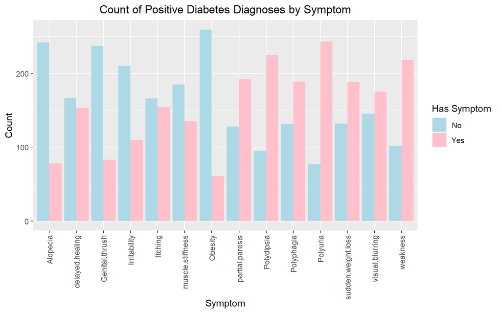

Table 1. P-values for each symptom’s correlation with diabetes

| Variable | P_Value |
| --- | --- |
| Polyuria | 1.740912e-51 |
| Polydipsia | 6.187010e-49 |
| Sudden weight loss | 5.969166e-23 |
| Weakness | 4.869843e-08 |
| Polyphagia | 1.165158e-14 |
| Genital thrush | 1.609790e-02 |
| Visual blurring | 1.701504e-08 |
| Itching | 8.297484e-01 |
| Irritability | 1.771483e-11 |
| Delayed healing | 3.266599e-01 |
| Partial paresis | 1.565289e-22 |
| Muscle stiffness | 6.939096e-03 |
| Alopecia | 1.909279e-09 |
| Obesity | 1.271080e-01 |

Table 2. General linearized model summary

```
Call:
glm(formula = class ~ Polyuria + Polydipsia + suddenweightloss +
    weakness + Polyphagia + genitalthrush + visualblurring +
    Irritability + partialparesis + musclestiffness + Alopecia,
    family = "binomial", data = data)

Coefficients:
                  Estimate Std. Error z value Pr(>|z|)
(Intercept)        -6.4362     0.7595  -8.474  < 2e-16 ***
Polyuria0           2.4649     0.4240   5.814 6.11e-09 ***
Polydipsia0         2.8550     0.4855   5.880 4.10e-09 ***
suddenweightloss0   0.8470     0.3840   2.206  0.02742 *
weakness0           0.2868     0.3613   0.794  0.42731
Polyphagia0         0.7417     0.3698   2.006  0.04486 *
genitalthrush0      0.7604     0.4014   1.894  0.05819 .
visualblurring0     0.4178     0.4392   0.951  0.34148
Irritability0       1.2569     0.4193   2.997  0.00272 **
partialparesis0     1.1204     0.3956   2.832  0.00462 **
musclestiffness0   -0.9593     0.4126  -2.325  0.02007 *
Alopecia0          -1.5495     0.3910  -3.963 7.41e-05 ***
---
Signif. codes:  0 '***' 0.001 '**' 0.01 '*' 0.05 '.' 0.1 ' ' 1

(Dispersion parameter for binomial family taken to be 1)

    Null deviance: 692.93  on 519  degrees of freedom
Residual deviance: 281.03  on 508  degrees of freedom
AIC: 305.03

Number of Fisher Scoring iterations: 7
```

The equation of this general linearized model can be defined as: n = -6.44 + 2.46(Polyuria) + 2.86(Polydipsia) + 0.85(Sudden weight loss) + 0.29(Weakness) + 0.74(Polyphagia) + 0.76(Genital thrush) + 0.42(Visual blurring) + 1.26(Irritability) + 1.12(Partial paresis) - 0.96(Muscle stiffness) - 1.55(Alopecia)

Graph 2. General linearized model coefficient plot

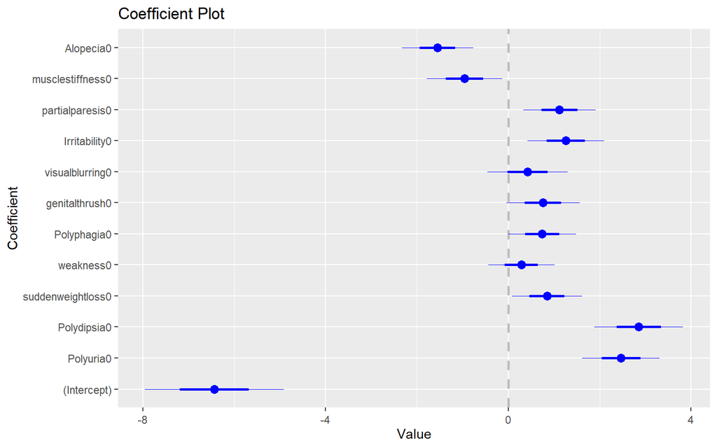

```r
library(coefplot)
coefplot(diabetes_glm)
```

# Results and conclusions

The results of this project may be used to determine the likelihood of a patient to be positive for diabetes based on theses symptoms. This will allow doctors and patients determine if a diabetes test should be conducted to determine their diagnosis.

# Limitations

There are multiple limitations when working with this dataset. First, all data was obtained through questionnaires and dependent on accurate responses from patients. Next, the sample size is also relatively low, with only 520 respondents, limiting the analysis that can be used. Additionally, the data were limited to binomial values, which also limits the analysis that can be conducted with this dataset.